# Week1_NT

```r
library(plyr)
library(magrittr)
library(data.table)
library(tidyverse)
library(lubridate)
```

## 과제 0

##### **R을 배운지 얼마 안 되어 아는 건 기본함수 밖에 없는 코딩 꿈나무가 어떤 지시문을 읽고 신나는 마음으로 전처리를 진행하였다. 기존의 코드를 다음과 같은 조건을 충족하여 다시 코딩해보자.**

```r
#data <- read.csv("데이터0.csv")
data <- fread("데이터0.csv")
```

`data.table`패키지 안에 있는 `fread`함수를 사용해 불러온다.

```r
#data$Petal.Length <- NULL
data %<>% mutate(Petal.Length = NULL)

#data <- data[data$Petal.Width <= 1.800, ]
data %<>% filter(Petal.Width <= 1.800)
```

```r
#data$Sepal_mean <- mean(data$Sepal.Length)
#data$Sepal_sd <- sqrt(var(data$Sepal.Length))
data %<>% mutate(Sepal_mean = mean(data$Sepal.Length))
data %<>% mutate(Sepal_sd = (data$Sepal.Length %>% var %>% sqrt))
```

mean과 sd 컬럼을 mutate로 추가한다.

```r
#data$Sepal.Width_mean_each <- NA
#data$num <- NA

#data$Sepal.Width_mean_each[data$Species == "virginica"] <- mean(data$Sepal.Width[data$Species ==
#                                                                                   "virginica"])
#data$Sepal.Width_mean_each[data$Species == "versicolor"] <- mean(data$Sepal.Width[data$Species ==
#                                                                                   "versicolor"])
#data$Sepal.Width_mean_each[data$Species == "setosa"] <- mean(data$Sepal.Width[data$Species == "setosa"])

#data$num[data$Species == "virginica"] <- length(data$num[data$Species == "virginica"])
#data$num[data$Species == "versicolor"] <- length(data$num[data$Species == "versicolor"])
#data$num[data$Species == "setosa"] <- length(data$num[data$Species == "setosa"])

data_mean <-
  data %>%
  group_by(Species) %>%
  summarise(Sepal.Width_mean_each = mean(Sepal.Width))
data %<>% left_join(data_mean, by = 'Species')

data_num <-
  data %>%
  group_by(Species) %>%
  summarise(num = n())
data %<>% left_join(data_num, by = 'Species')
```

`data_mean`과 `data_num`이라는 Species에 따른 평균과 개체수에 대한 데이터프레임을 새로 만들고, 이를 원래 데이터에 `left_join`한다.

```r
#data <- data[data$Sepal.Length %>% order(decreasing = T), ]
data %<>% arrange(desc(Sepal.Length))
```

`arrange`함수를 사용해서 정렬한다.

```r
#data$Species <- as.character(data$Species)
#data$Species[data$Species == "virginica"] <- "VI"
#data$Species[data$Species == "versicolor"] <- "VE"
#data$Species[data$Species == "setosa"] <- "SE"
#data$Species <- as.factor(data$Species)

data$Species %<>%
  revalue(c('virginica' = 'VI', 'versicolor' = 'VE', 'setosa' = 'SE')) %>%
  as.factor
```

이미 character라 `ungroup`함수를 사용하지 않았다. `revalue`함수를 통해 값을 변환해주고, factor형으로 바꿔준다.

```r
#colnames(data)[colnames(data) == "Species"] <- "name"
data %<>% rename(name = Species)
```

`rename` 함수를 사용해 컬럼명을 바꿔준다.

```r
data %>% head # 결과물 확인
```

```
##   Sepal.Length Sepal.Width Petal.Width name Sepal_mean Sepal_sd
## 1          7.3         2.9         1.8   VI   5.590517 0.699811
## 2          7.2         3.2         1.8   VI   5.590517 0.699811
## 3          7.2         3.0         1.6   VI   5.590517 0.699811
## 4          7.0         3.2         1.4   VE   5.590517 0.699811
## 5          6.9         3.1         1.5   VE   5.590517 0.699811
## 6          6.8         2.8         1.4   VE   5.590517 0.699811
##   Sepal.Width_mean_each num
## 1                 2.825  16
## 2                 2.825  16
## 3                 2.825  16
## 4                 2.770  50
## 5                 2.770  50
## 6                 2.770  50
```

## 과제 1

#### **1. [데이터1.csv]를 불러오고 그 str 및 summary를 확인해보자**

```r
data <- fread("데이터1.csv")
data %>% dim # dimension 확인, 59009행 32열
```

```
## [1] 59009    32
```

```r
data %>% str
```

```
## Classes 'data.table' and 'data.frame':   59009 obs. of  32 variables:
##  $ click                 : int  0 0 0 0 0 0 0 0 0 0 ...
##  $ event_datetime        : chr  "2019-10-10 10:56:22.630" "2019-10-09 03:45:41.290" "2019-10-03 08:44:09.192" "2019-10-09 00:02:36.144" ...
##  $ bid_id                : chr  "UC9cToa1lW" "fRWvRbFrFm" "OUXau6CTY8" "nXg9gWWdY6" ...
##  $ ssp_id                : chr  "ddtzah8tWp" "nwf1A3O5cO" "VKAHCb2KFB" "M6QaRvdZ8h" ...
##  $ campaign_id           : chr  "6MHXVqZ5r7" "soNcvXzOZg" "7Kwt6e0pY7" "RxEczLJS45" ...
##  $ adset_id              : chr  "9Vs8t2QPht" "XsxDfbHZk4" "AG7qEYSHUh" "jooulmYwop" ...
##  $ placement_type        : chr  "1pcQ3RJgQt" "kIeE1J0KCa" "kIeE1J0KCa" "kIeE1J0KCa" ...
##  $ media_id              : chr  "hLR1pJk4Us" "sRqCheOKW4" "hLuV0aqEVp" "Cp0TOgEAEB" ...
##  $ media_name            : chr  "Rmr6xB6bN1" "n0p3m00ieQ" "Xbdchs5uK3" "EajTk3ilNf" ...
##  $ media_bundle          : chr  "lxiZbb3bG8" "LfFPsJWJSf" "0tlqbS6Nf5" "AFk4AYEOyt" ...
##  $ media_domain          : chr  "pjBT3sDGbH" "pjBT3sDGbH" "pjBT3sDGbH" "pjBT3sDGbH" ...
##  $ publisher_id          : chr  "ZKL5lpzDZo" "dShknap9uf" "FpOvhbPDXd" "vjSjiBHBO7" ...
##  $ publisher_name        : chr  "Abg0jYuxSE" "N8djnVWnYo" "BnqjbSLXhH" "dDz4Byog6d" ...
##  $ device_ifa            : chr  "N8iTdgNfWN" "0BVuqZ2Gb2" "xyFIR0yYgF" "q11EDogjCE" ...
```

[output cut: 19 more lines]

```r
data %>% summary
```

```
##      click        event_datetime        bid_id             ssp_id
##  Min.   :0.0000   Length:59009       Length:59009       Length:59009
##  1st Qu.:0.0000   Class :character   Class :character   Class :character
##  Median :0.0000   Mode  :character   Mode  :character   Mode  :character
##  Mean   :0.1147
##  3rd Qu.:0.0000
##  Max.   :1.0000
##
##  campaign_id          adset_id         placement_type       media_id
##  Length:59009       Length:59009       Length:59009       Length:59009
##  Class :character   Class :character   Class :character   Class :character
##  Mode  :character   Mode  :character   Mode  :character   Mode  :character
##
##
##
##
##   media_name        media_bundle       media_domain       publisher_id
##  Length:59009       Length:59009       Length:59009       Length:59009
##  Class :character   Class :character   Class :character   Class :character
##  Mode  :character   Mode  :character   Mode  :character   Mode  :character
##
##
##
##
##  publisher_name      device_ifa         device_os         device_os_version
##  Length:59009       Length:59009       Length:59009       Length:59009
##  Class :character   Class :character   Class :character   Class :character
##  Mode  :character   Mode  :character   Mode  :character   Mode  :character
##
##
##
##
##  device_model       device_carrier     device_make
##  Length:59009       Length:59009       Length:59009
##  Class :character   Class :character   Class :character
##  Mode  :character   Mode  :character   Mode  :character
##
##
##
##
```

[output cut: 17 more lines]

```
##  Length:59009       Length:59009       Length:59009       Length:59009
##  Class :character   Class :character   Class :character   Class :character
##  Mode  :character   Mode  :character   Mode  :character   Mode  :character
##
##
##
##
##  predicted_house_price asset_index
##  Min.   :   320        Mode:logical
##  1st Qu.:  8750        NA's:59009
##  Median : 16300
##  Mean   : 22408
##  3rd Qu.: 28000
##  Max.   :320000
##  NA's   :6506
```

```r
data %>% glimpse
```

```
## Observations: 59,009
## Variables: 32
## $ click                  <int> 0, 0, 0, 0, 0, 0, 0, 0, 0, 0, 0, 0, 0, 0, 1,...
## $ event_datetime         <chr> "2019-10-10 10:56:22.630", "2019-10-09 03:45...
## $ bid_id                 <chr> "UC9cToa1lW", "fRWvRbFrFm", "OUXau6CTY8", "n...
## $ ssp_id                 <chr> "ddtzah8tWp", "nwf1A3O5cO", "VKAHCb2KFB", "M...
## $ campaign_id            <chr> "6MHXVqZ5r7", "soNcvXzOZg", "7Kwt6e0pY7", "R...
## $ adset_id               <chr> "9Vs8t2QPht", "XsxDfbHZk4", "AG7qEYSHUh", "j...
## $ placement_type         <chr> "1pcQ3RJgQt", "kIeE1J0KCa", "kIeE1J0KCa", "k...
## $ media_id               <chr> "hLR1pJk4Us", "sRqCheOKW4", "hLuV0aqEVp", "C...
## $ media_name             <chr> "Rmr6xB6bN1", "n0p3m00ieQ", "Xbdchs5uK3", "E...
## $ media_bundle           <chr> "lxiZbb3bG8", "LfFPsJWJSf", "0tlqbS6Nf5", "A...
## $ media_domain           <chr> "pjBT3sDGbH", "pjBT3sDGbH", "pjBT3sDGbH", "p...
## $ publisher_id           <chr> "ZKL5lpzDZo", "dShknap9uf", "FpOvhbPDXd", "v...
## $ publisher_name         <chr> "Abg0jYuxSE", "N8djnVWnYo", "BnqjbSLXhH", "d...
```

[output cut: 19 more lines]

`glimpse`는 `str`보다 빠르고, 더 간편한 함수. `dplyr`안에 내장

#### **2. 각 변수(열)마다 ‘유니크’한 값들이 몇 개인지 알아보자**

```r
data_df <- data %>% data.frame()
# 인덱싱이 불편해서 잠깐만 확인하기 위해 데이터 프레임으로!
for(i in 1:32) {
  len <- data_df[, i] %>% unique %>% length
  name_col <- colnames(data_df)
  cat(i, '열', name_col[i], '의 유니크한 값의 개수는 ', len, '개 이다.\n')
}
```

```
## 1 열 click 의 유니크한 값의 개수는  2 개 이다.
## 2 열 event_datetime 의 유니크한 값의 개수는  59004 개 이다.
## 3 열 bid_id 의 유니크한 값의 개수는  59009 개 이다.
## 4 열 ssp_id 의 유니크한 값의 개수는  17 개 이다.
## 5 열 campaign_id 의 유니크한 값의 개수는  175 개 이다.
## 6 열 adset_id 의 유니크한 값의 개수는  758 개 이다.
## 7 열 placement_type 의 유니크한 값의 개수는  4 개 이다.
## 8 열 media_id 의 유니크한 값의 개수는  1064 개 이다.
## 9 열 media_name 의 유니크한 값의 개수는  914 개 이다.
## 10 열 media_bundle 의 유니크한 값의 개수는  746 개 이다.
## 11 열 media_domain 의 유니크한 값의 개수는  63 개 이다.
## 12 열 publisher_id 의 유니크한 값의 개수는  571 개 이다.
## 13 열 publisher_name 의 유니크한 값의 개수는  375 개 이다.
## 14 열 device_ifa 의 유니크한 값의 개수는  38168 개 이다.
## 15 열 device_os 의 유니크한 값의 개수는  1 개 이다.
```

[output cut: 17 more lines]

```r
rm(data_df)  # 쓸데없이 메모리 차지하지 않게 지우기
```

#### **3. str, summary, 유니크한 값들의 숫자들의 정보를 보았을 때 지워야할 열을 지우고 그 이유를 간략하게 설명해보자**

```r
data %<>% mutate(device_os = NULL,
                device_country = NULL,
                asset_index = NULL,
                bid_id = NULL)
```

15열 `device_os`, 22열 `device_country`, 32열 `asset_index`는 하나의 값밖에 없고, `asset_index`는 자체로 결측치다. 이 세개를 지운다. 또한 지나치게 유니한 값이 많은 경우, 그냥 지칭하는 정도이거나 모델 피팅에 어려움을 줄 수 있다.현재 `bid_id`는 아이디인데 지워도 무방할듯.

gender나 marry는 2개인게 맞고, device_ifa나 cate_code, install_pack의 경우 보너스 문제와 연결되니 남겨둔다.

#### **4. [age] 변수는 명목형 범주이기 때문에 명목 변수로 바꿔 주자**

```r
data %<>% mutate(age = as.character(age))
```

#### **5. 파생변수를 만들어보자**

##### **5-1. [event_datetime] 을 가지고 [주말 여부]와 [요일], [시간] 변수를 만들기. 시간 변수와 요일변수는 둘다 명목형이 되도록 하여라.**

```r
data %<>% mutate(day_of_week = data$event_datetime %>% lubridate::wday(label = T) %>% as.character(),  #요일변수
                date = data$event_datetime %>% day %>% str_pad(2, side = 'left', pad = '0'), # 일
                hour = data$event_datetime %>% hour %>% str_pad(2, side = 'left', pad = '0'),  #시
                minute = data$event_datetime %>% minute,
                second = data$event_datetime %>% second %>% round(),
                time = paste(hour, minute, second, sep = '.'), #시간
                minute = NULL, second = NULL,
                weekend = ifelse(day_of_week %in% c('일', '토'), 'Y', 'N'))# 주말여부
```

확인했을 때, integer를 제외하면 전부 character다.

##### **5-2. [event_datetime] 과 [click] 을 가지고 [시간당 평균 클릭율] 변수를 만들기**

```r
click_rate <-
  data %>%
  select(hour, click, date) %>%
  group_by(hour, date) %>%
  summarise(click_rate_hour = mean(click) %>% round(4)) %>%
  arrange(date)

data %<>% left_join(click_rate, by = c('hour', 'date'))
```

시간당 평균 클릭율 변수 만듬.

##### **5-3. [install_pack] 을 가지고 [설치되어 있는 앱의 갯수] 변수를 만들기**

```r
data %<>% mutate(total_app = (data$install_pack %>% str_count(',')) + 1)
```

`,`로 앱 번호가 나눠져 있기 때문에, `,`개수에 1 더한만큼이 설치된 앱의 개수이다. `stringr`패키지의 `str_count`함수를 사용해 변수를 만든다.

```r
data %>% glimpse()
```

```
## Observations: 59,009
## Variables: 35
## $ click                  <int> 0, 0, 0, 0, 0, 0, 0, 0, 0, 0, 0, 0, 0, 0, 1,...
## $ event_datetime         <chr> "2019-10-10 10:56:22.630", "2019-10-09 03:45...
## $ ssp_id                 <chr> "ddtzah8tWp", "nwf1A3O5cO", "VKAHCb2KFB", "M...
## $ campaign_id            <chr> "6MHXVqZ5r7", "soNcvXzOZg", "7Kwt6e0pY7", "R...
## $ adset_id               <chr> "9Vs8t2QPht", "XsxDfbHZk4", "AG7qEYSHUh", "j...
## $ placement_type         <chr> "1pcQ3RJgQt", "kIeE1J0KCa", "kIeE1J0KCa", "k...
## $ media_id               <chr> "hLR1pJk4Us", "sRqCheOKW4", "hLuV0aqEVp", "C...
## $ media_name             <chr> "Rmr6xB6bN1", "n0p3m00ieQ", "Xbdchs5uK3", "E...
## $ media_bundle           <chr> "lxiZbb3bG8", "LfFPsJWJSf", "0tlqbS6Nf5", "A...
## $ media_domain           <chr> "pjBT3sDGbH", "pjBT3sDGbH", "pjBT3sDGbH", "p...
## $ publisher_id           <chr> "ZKL5lpzDZo", "dShknap9uf", "FpOvhbPDXd", "v...
## $ publisher_name         <chr> "Abg0jYuxSE", "N8djnVWnYo", "BnqjbSLXhH", "d...
## $ device_ifa             <chr> "N8iTdgNfWN", "0BVuqZ2Gb2", "xyFIR0yYgF", "q...
```

[output cut: 22 more lines]

지금까지 만든 과정을 다시 확인한다.

#### **6. 언급된 파생변수를 다 만들었다면, [event_datetime]과 같은 시간 데이터를 제외하고 모든 character 클래스를 factor 클래스로 바꾸자**

```r
want_col = colnames(data) %>%
  setdiff(c('click', 'event_datetime', 'predicted_house_price', 'click_rate_hour', 'total_app'))
data[, want_col] = lapply(data[, want_col], factor)
```

`mutate_if`를 활용할수도 있었지만, `event_datetime`을 건드리고 싶지 않아서 그냥 `lapply`를 활용했다. `mutate_if`가 더 간편할듯!

#### **7. [cate_code] 는 트랜잭션 데이터의 형태, 어떤 식으로 활용할 수 있는지 설명해보고 전처리를 진행해보자**

클러스터링이 가능할듯? 앱번호를 컬럼으로, 각 사람을 로우로 해서, 안깔려있으면 0, 나머지는 원래 갖고 있던 숫자를 배정! 이 정보로 클러스터링을 해서 유의미한 정보 얻을 수 있을 것 같다!

```r
cate_code <- data$cate_code %>% as.character()

all_cate_vector <- NULL
each_cate_list <- list(NULL)
each_cate_score <- list(NULL)

for (i in 1:59009) {
  each_cate_list[i] <- cate_code[i] %>% str_split(',') %>% str_extract_all('[a-z0-9]\\d\\d\\d\\d')
  each_cate_score[i] <- cate_code[i] %>% str_split(',')
  each_cate_list[[i]] <- each_cate_list[[i]] %>% sort
  each_cate_score[[i]] <- each_cate_score[[i]] %>% sort
  all_cate_vector <- all_cate_vector %>% union(each_cate_list[[i]])
#  if (i %% 5000 == 0) {
#    cat('i is', i, '\t')
#  }
}

each_cate_list[[5000]]
```

```
##  [1] "01001" "01002" "01004" "01005" "02005" "03006" "04007" "04012" "04013"
## [10] "06001" "06003" "06006" "06007" "06009" "08001" "09001" "09005" "09006"
## [19] "12013" "13001" "13002" "14003" "14004" "14005" "15001" "15003" "15004"
## [28] "16001" "16002" "16004" "16006" "18001" "18002" "18004" "18006" "19001"
## [37] "19002" "19011" "20007" "20008" "21001" "21007" "21009" "21011" "21013"
## [46] "21015" "23005" "24001" "p0005" "p0010" "p0017" "p0020"
```

```r
each_cate_score[[5000]]
```

```
##  [1] "01001:3" "01002:1" "01004:1" "01005:2" "02005:1" "03006:1" "04007:3"
##  [8] "04012:3" "04013:2" "06001:3" "06003:1" "06006:1" "06007:1" "06009:1"
## [15] "08001:2" "09001:3" "09005:4" "09006:1" "12013:4" "13001:1" "13002:3"
## [22] "14003:3" "14004:2" "14005:1" "15001:1" "15003:2" "15004:4" "16001:1"
## [29] "16002:1" "16004:1" "16006:3" "18001:4" "18002:1" "18004:1" "18006:1"
## [36] "19001:1" "19002:1" "19011:1" "20007:3" "20008:5" "21001:1" "21007:1"
## [43] "21009:3" "21011:1" "21013:2" "21015:4" "23005:5" "24001:3" "p0005:4"
## [50] "p0010:2" "p0017:2" "p0020:2"
```

`each_cate_list`는 앱번호?만을 가져오고, `each_cate_score`는 앱번호와 점수를 동시에 가져온다. 이때 5자리 번호만이 아니라, `p0015`와 같은 형태의 앱번호가 있기 때문에, 정규표현식을 쓸 때 맨 앞자리를 알파벳과 숫자를 동시에 고려한다. 각각 벡터화하고, sorting해준다. 그리고 전체 앱번호들의 집합을 `union`함수를 통해 만들어준다. 반환된 값을 확인해보니, 잘되었다!

```r
all_cate_vector %<>% sort
n_row <- 59009
n_col <- all_cate_vector %>% length ; n_col # 241개
```

```
## [1] 241
```

```r
cate_list <- list(NULL)
cate_mat <- matrix(NA, nrow = n_row, ncol = n_col)
colnames(cate_mat) <- all_cate_vector

each_row_vec <- NULL
for (i in 1:n_row) {
  each_row_vec <- all_cate_vector %in% intersect(all_cate_vector, each_cate_list[[i]])
  cate_mat[i, ] <- each_row_vec
#  if ( i %% 5000 == 0) {
#    cat('i is', i,'\t')
#  }
}
```

관측치의 개수만큼 row를 만들고, cate의 개수만큼 column을 만든다. 그리고 각각의 관측치가 column의 값을 갖고 있는지 여부에 따라 1,0 (T,F)를 매겨준다.

```r
compare_vector <- NULL
for (i in 1:n_row) {
  compare_vector <- cate_mat[i, ]
  compare_vector[compare_vector == T] <-
    each_cate_score[[i]] %>% str_extract_all(':[1-5]') %>% unlist %>% str_remove_all(':') %>% as.integer()
  cate_mat[i, ] <- compare_vector
}

cate_mat[1:20, 1:20]
```

```
##       01001 01002 01003 01004 01005 01006 01007 01008 01009 01010 01011 02001
##  [1,]     0     2     0     3     0     0     0     0     0     0     0     0
##  [2,]     0     2     0     0     0     0     0     0     0     0     0     0
##  [3,]     0     0     2     4     0     0     1     0     0     0     0     0
##  [4,]     0     5     2     4     0     0     0     0     0     0     0     0
##  [5,]     0     1     1     5     0     0     0     0     0     0     0     0
##  [6,]     0     0     0     3     0     0     0     0     0     0     0     0
##  [7,]     3     5     2     0     0     0     2     0     0     0     0     0
##  [8,]     0     0     0     0     3     0     0     0     0     0     0     0
##  [9,]     0     5     4     0     0     0     0     0     0     0     0     0
## [10,]     1     2     3     0     1     0     0     0     0     0     0     0
## [11,]     0     2     3     0     1     0     0     0     0     0     0     0
## [12,]     0     5     2     3     0     0     0     0     1     0     0     0
## [13,]     1     2     3     0     3     0     0     0     0     0     0     0
## [14,]     0     1     4     0     0     0     0     0     0     0     0     0
```

[output cut: 27 more lines]

그러면 T를 매긴 값들만 1~5로 숫자를 만들어주려고 한다. `each_cate_score`에서 숫자만 뽑아내고, 각각 row에서 `T`인 값들에 넣어주면 된다. 이미 서로 sorting된 상황이기 때문에 순서의 문제는 없다.

#### **8. [install_pack] 도 마찬가지로 트랜잭션 데이터, 위에서는 설치된 앱의 숫자를 얻기 위해서만 썼는데 다른 어떤 방식으로 사용할 수 있는지 설명해보고 마찬가지로 가능하다면 전처리를 진행해보기**

row는 관측치, column은 앱이름. 어떤 앱이 깔려있으면 1, 없으면 0을 배정한다. 그 매트릭스에 대해 클러스터링?유사도?를 구하면 무언가 유의미한 결과물을 얻을 수 있지 않을까?

전체적인 과정은 7번과 비슷하다. 7번은 TF를 메기고, T에 대해 score를 부과하는 방식이었다면, 여기는 TF만 고려하면 되서 더 간단하다. 앱 개수의 차이가 매우 커서, 좀 느리긴하다. 방식을 똑같으니 설명은 생략한다.

메모리 한계로 뒤의 코드는 실행하진 않겠다. 7번하고 유사하니 작동에는 문제가 없다.

```r
install_pack <- data$install_pack

n_row = 59009
all_install_vector <- NULL
each_install_list <- list(NULL)

for (i in 1:n_row) {
  each_install_list[i] <- install_pack[i] %>% str_split(',') %>% str_extract_all('\\d\\d\\d\\d\\d')
  each_install_list[[i]] <- each_install_list[[i]] %>% sort()
  all_install_vector <- all_install_vector %>% union(each_install_list[[i]])
  if (i %% 5000 == 0) {
    cat('i is', i, '\t')
  }
}
```

```r
# all_install_vector # 28243개

install_df <- matrix(NA, nrow = n_row, ncol = length(all_install_vector))
colnames(install_df) <- all_install_vector

each_row_vec <- NULL
for (i in 1:n_row) {
  each_row_vec <- all_install_vector %in% intersect(all_install_vector, each_install_list[[i]])
  install_df[i, ] <- each_row_vec
  if ( i %% 5000 == 0) {
    cat('i is', i,'\t')
  }
}

install_df[1:10,1:15]  # 잘나옴!
```

### **시각화 문제**

```r
library(gridExtra)
```

여러 그래프를 합치기 위해 사용한다.

#### **1. 위의 만들어진 데이터를 통하여 다음과 같은 시각화 그래프를 만들고 간략하게 얻은 인사이트를 설명해보자**

```
## geom_path: Each group consists of only one observation. Do you need to adjust
## the group aesthetic?
```

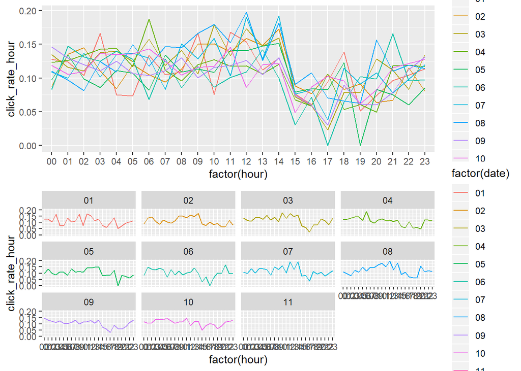

```r
firstplot <-
  ggplot(click_rate, aes(x = factor(hour), y = click_rate_hour)) +
  geom_line(aes(color = factor(date), group = factor(date)))

secondplot <-
  ggplot(click_rate, aes(x = factor(hour), y = click_rate_hour)) +
  geom_line(aes(color = factor(date), group = factor(date))) +
  facet_wrap(vars(date), nrow = 3)

grid.arrange(firstplot, secondplot, nrow = 2)
```

15~21시 까지는 클릭율이 상대적으로 저조하다. 이게 정확히 어떤 의미를 갖는지 조금 해석하기 어렵다. 일하는 시간에 생각보다 클릭을 잘하는데, 근데 왜 잠자야 하는 시간에도 클릭율이 유지가 되는지 의아하다. 어떤 요인이 이런 그래프를 만드는지 좀더 고려해야할 것 같다. 이때 주말 여부도 동시에 고려해주는게 더 좋은 이해를 얻을 것 같다.

#### **2. 위의 만들어진 데이터를 통하여 다음과 같은 시각화 그래프를 만들어보자**

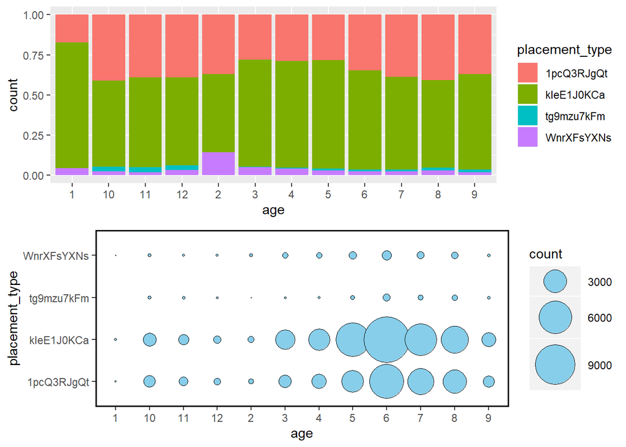

```r
first_plot <-
  ggplot(data) +
  geom_bar(aes(x = age, fill = placement_type), position = 'fill')

second_plot <-
  data %>%
  group_by(age, placement_type) %>%
  summarise(count = n()) %>%
  ggplot() +
  geom_point(aes(x = age, y = placement_type, size = count),
             shape = 21, color = 'black', fill = 'skyblue') +
  theme(panel.background=element_blank(), panel.border = element_rect(fill=NA, size=1)) +
  scale_size_area(max_size = 17)

grid.arrange(first_plot, second_plot, nrow = 2)
```

`placement_type` 중 `kleE1J0KCa`의 비율이 매우 높다. balloon plot상에서도 이는 드러나며, `age`의 경우 6에 해당하는 그룹이 가장 많다.

#### **3. 위의 만들어진 데이터를 통하여 다음과 같은 시각화 그래프를 만들어 보자!**

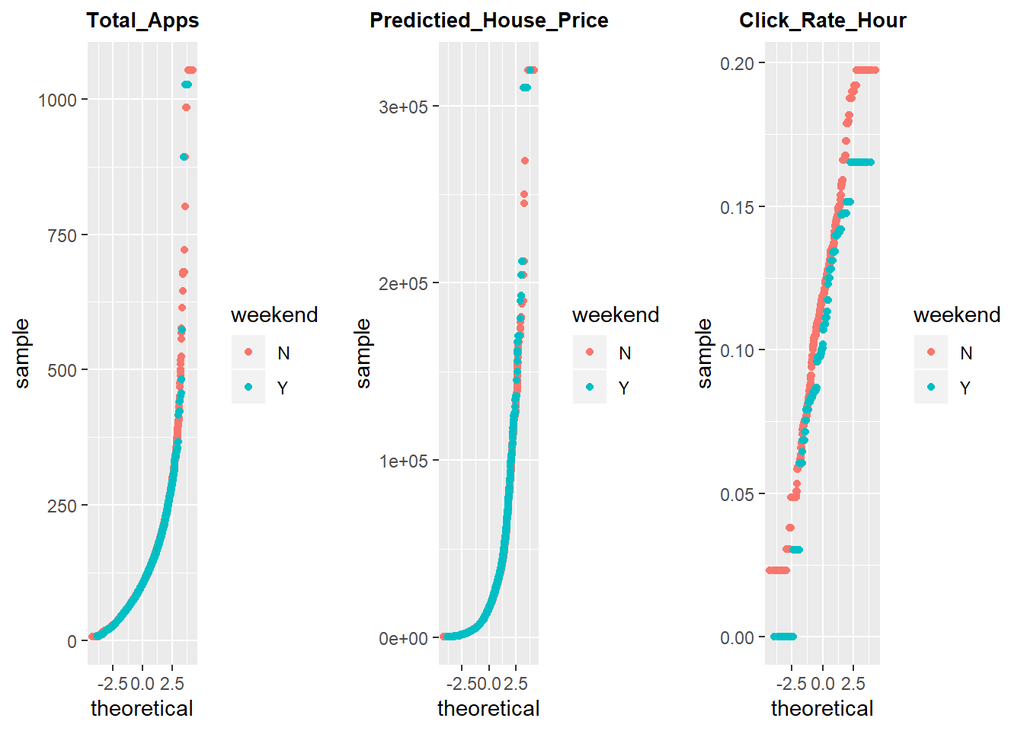

```r
plot1 <-
  ggplot(data, aes(sample = as.integer(total_app))) +
  stat_qq(aes(color = weekend)) +
  ggtitle('Total_Apps') +
  theme(plot.title = element_text(size = 10, face = "bold", hjust = 0.5))
plot2 <-
  ggplot(data, aes(sample = predicted_house_price)) +
  stat_qq(aes(color = weekend)) +
  ggtitle('Predictied_House_Price') +
  theme(plot.title = element_text(size = 10, face = "bold", hjust = 0.5))
plot3 <-
  ggplot(data, aes(sample = click_rate_hour)) +
  stat_qq(aes(color = weekend))+
  ggtitle('Click_Rate_Hour') +
  theme(plot.title = element_text(size = 10, face = "bold", hjust = 0.5))
finalplot1 <- grid.arrange(plot1, plot2, plot3, ncol = 3)
```

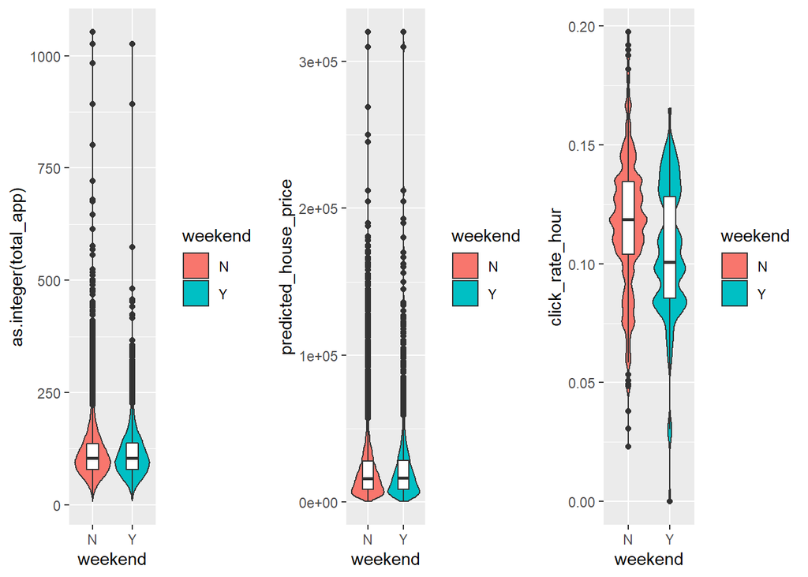

```r
plot1 <-
  ggplot(data, aes(x = weekend, y = as.integer(total_app))) +
  geom_violin(aes(fill = weekend)) +
  geom_boxplot(width = 0.3)
plot2 <-
  ggplot(data, aes(x = weekend, y = predicted_house_price)) +
  geom_violin(aes(fill = weekend)) +
  geom_boxplot(width = 0.3)
plot3 <-
  ggplot(data, aes(x = weekend, y = click_rate_hour)) +
  geom_violin(aes(fill = weekend)) +
  geom_boxplot(width = 0.3)
finalplot2 <- grid.arrange(plot1, plot2, plot3, ncol = 3)
```

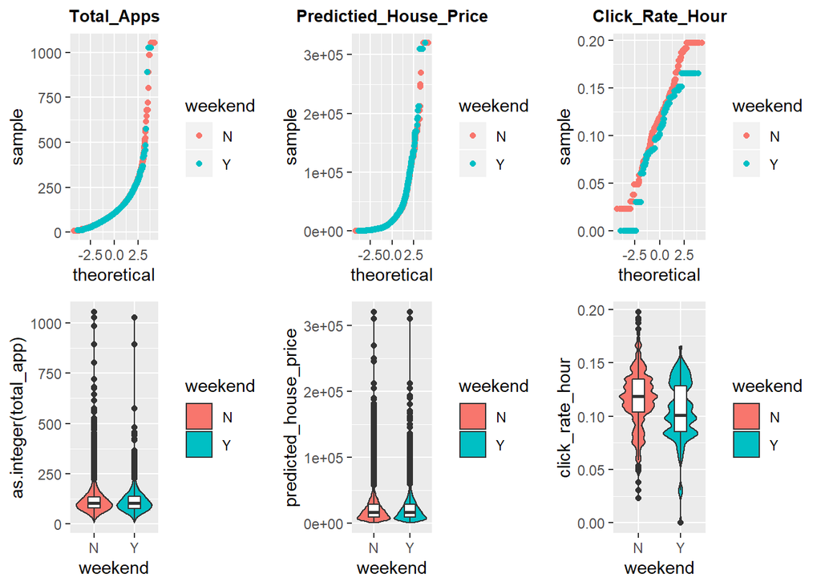

```r
grid.arrange(finalplot1, finalplot2, nrow = 2)
```

qq플랏은 `stat_qq`를 통해, violin plot과 box plot은 그래픽 함수를 사용해 그렸다. 명확히 드러나는 차이는 시간당 클릭율이 주말보다는 주중에 높다는 것이다.